# Tutorial 3- Medidas de autocorrelación e introducción al análisis de Fourier

### Noel Isaías Placencia-Díaz, Erin C. McKiernan, Marco Arieli Herrera-Valdez,

### Facultad de Ciencias, UNAM

```python
%matplotlib inline
```

```python
import numpy as np
import matplotlib.pyplot as plt
```

## Tabla de contenidos:

1. Introducción

2. Diagrama de Poncairé

3. Función de autocorrelación

4. Introducción al análisis de Fourier

4.1 Transformada de Fourier

4.2 Densidad del espectro de frecuencias

## 1. Introducción - Medidas de autocorrelación

En ocasiones los registros de datos fisiológicos pueden presentar patrones de repetición a lo largo del tiempo, ejemplos de esto los podemos encontrar en fenómenos como la fotosíntesis, el ritmo cardiaco, la respiración, la temperatura corporal, la actividad motora y cerebral, entre otros. A estos patrones se les conoce como $\textit{ritmos fisiológicos}$ y estudiar la presencia o ausencia de ellos en ciertas funciones corporales, así como la modificación de estos mismos ante estímulos externos es de vital interés, pues los ritmos fisiológicos reflejan la actividad a gran escala de los mecanismos biológicos subyacentes en el organismo.

Una forma de detectar la presencia de patrones repetitivos es a través de la autocorrelación. De forma intuitiva, la autocorrelación es una medida de $\textit{cuánto se parece una señal a si misma}$, en este tutorial mediremos correlaciones a corto plazo temporal utilizando el $\textit{Diagrama de dispersión de Poncairé}$ y correlaciones a largo plazo utilizando la $\textit{función de autocorrelación}$.

##### Electoencefalograma

Primero vamos a extraer los datos y su escala de tiempo como lo hemos hecho anteriormente, en este caso, analizaremos datos correspondientes a un electroencefalograma (EEG):

```python
eeg = np.genfromtxt("testdata_eeg", delimiter=",")
samp_rate = 256.0
tiempo = np.arange(0,len(eeg))*(1/samp_rate)
```

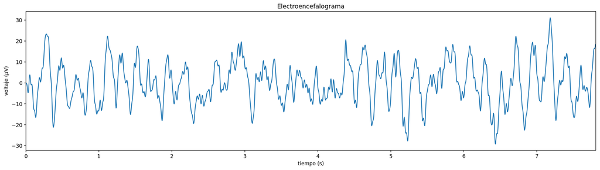

```python
# Plot EEG signal
fig = plt.figure(figsize=(20, 5), dpi=100)
plt.figure(1)

plt.title('Electroencefalograma')
plt.xlabel(r'tiempo (s)')
plt.ylabel(r'voltaje ($\mu$V)')
plt.grid=True


plt.plot(tiempo,eeg)
plt.xlim(0,max(tiempo))
plt.grid=True

plt.show()
```

### 2. Diagrama de dispersión de Poncairé

Esta es una herramienta de análisis que nos permite encontrar correlaciones a corto plazo en una serie de tiempo, esta herramienta es usualmente utilizada en estudios series de tiempo fisiológicas (https://www.researchgate.net/publication/289971706_Poincare_plots_in_analysis_of_heart_rate_variability) y adquiere aún más utilidad cuando se conocen las periodicidades de la serie de tiempo analizada.

El diagrama de dispersión de Poncairé, tambien conocido como reconstrucción temporal del espacio fase, consiste en graficar la serie de tiempo estudiada contra si misma pero trasladada en un número determinado de puntos ($\textit{lag}$).

Para un $\textit{lag}$ dado, si el diagrama se aproxima a una línea recta, podemos decir que los datos son muy similares, en cambio, si el diagrama se asemeja más a un círculo, podemos decir que no hay relación entre los datos, como es de imaginar, el punto medio entre estos dos comportamientos lo encontramos cuando el diagrama se asemeja más a una elipse.

```python
def Poncaire_Diagram(signal,lag):

    plt.figure(figsize=(3,3), dpi=200)
    plt.figure(1)

    plt.plot(signal[:len(signal)-lag],signal[lag:],marker="+",ms=.2,lw=0)

    plt.axis('on')
    plt.draw()
    plt.show()
```

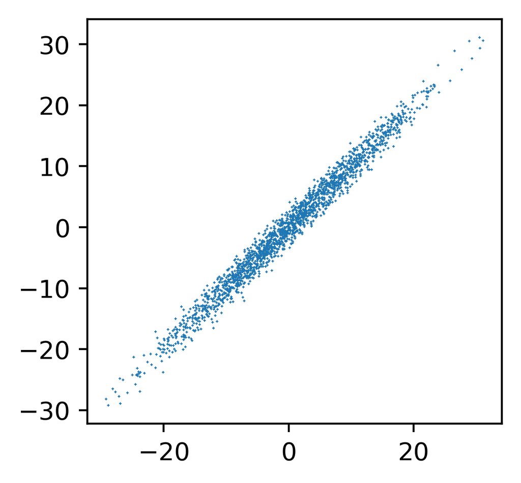

```python
Poncaire_Diagram(eeg,1)
```

### 3. Función de autocorrelación

Esta es la forma más comunmente utilizada para encontrar patrones de periodicidad en una señal, incluso resulta útil para detectar el periodo de repetición de la misma

```python
def autocorr(x):
    result = np.correlate(x, x, mode='full')
    half=int(result.size/2)
    return result[half:]/max(result[half:])
```

```python
A = (autocorr(eeg))
```

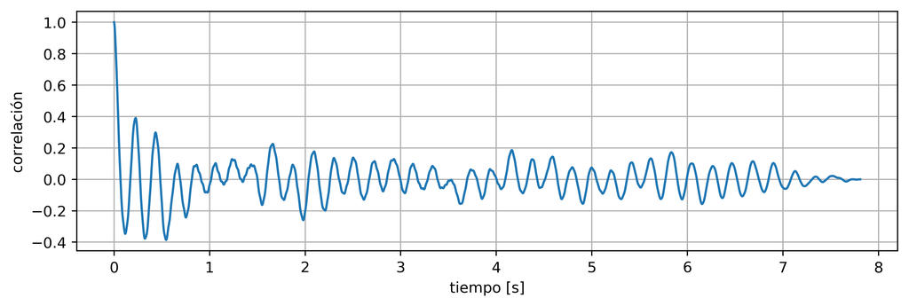

```python
fig = plt.figure(figsize=(10, 3), dpi=200)

ax = fig.add_subplot(1, 1, 1)
ax.set_xlabel('tiempo [s]')
ax.set_ylabel('correlación')
ax.grid(True)
#ax.set_xscale(10)

ax.plot(tiempo,A)
```

## 4. Introducción al análisis de Fourier

El teorema de representación en series de Fourier es un resultado muy fuerte del análisis de funciones, este teorema nos dice que cualquier función $f(x)$ que cumplan con ser:

$$\textbf{1) periódica}$$

$$\textbf{2) continua}$$

$$\textbf{3) suave a tramos}$$,

puede expresarse como una suma de senos y cosenos con amplitudes y frecuencias distintas. Esto se escribe como:

$$ f(x) = \frac{a_{0}}{2} + {{\sum_{n=1}^\infty(a_{n} cos(\frac{2\pi n}{P}x) + b_{n} sen(\frac{2\pi n}{P}x) ) }} $$

donde $P$ es el periodo de $f(x$) y $a_{n}$, $b_{n}$ son los coeficientes de Fourier que indican la contribución de cada seno y coseno de la serie, estos se obtienen de la siguiente forma:

$$ a_{0} = \int_{0}^{P} f(x) dx $$ $$ a_{n} = \int_{0}^{P} f(x) cos(\frac{2\pi n}{P}x) dx $$ $$ b_{n} = \int_{0}^{P} f(x) sen(\frac{2\pi n}{P}x) dx $$

En otras palabras, representar una función como su serie de Fourier es equivalente a encontrar las frecuencias que la componen y determinar qué tanto contribuyen dentro de la función original. Esto hace que el análisis de Fourier sea de las herramientas más ampliamente utilizadas en el análisis y procesamiento de señales.

Es importante recalcar que el análisis de Fourier sólo es adecuado mientras la serie de tiempo analizada cumpla (al menos de forma aproximada) con las propiedades 1), 2) y 3). De otra forma, los resultados pueden ser engañosos por lo que es recomendable llevar a cabo otros métodos de análisis.

### 4.1 Transformada de Fourier

La transformada de Fourier nos permite observar una función exclusivamente en términos de sus frecuencias constitutivas, se dice que se esta es la representación de la función en el $\textit{dominio de las frecuencias}$ (también espacio de fecuencias o espacio recíproco); por otro lado, se dice que la señal original, en términos de las variables tiempo-voltaje, está en el $\textit{dominio del tiempo}$.

Aplicaremos la transformada de Fourier al los datos del EEG para obtener las frecuencias predominantes del registro.

```python
frq = np.fft.rfft(eeg) #Obtiene la transformada de Fourier discreta de 'eeg', a través de un algoritmo llamado fast fourier transform (fft)
```

Ahora graficaremos el EEG en dominios del tiempo y de frecuencias:

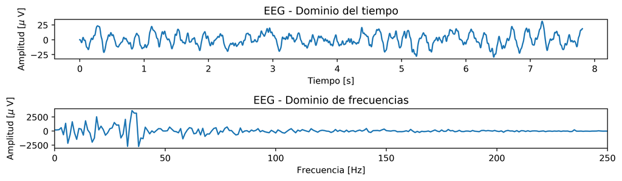

```python
fig = plt.figure(figsize=(10, 3), dpi=200)

ax = fig.add_subplot(2, 1, 1)
ax.set_xlabel('Tiempo [s]')
ax.set_ylabel('Amplitud [$\mu$ V]')
ax.set_title('EEG - Dominio del tiempo')


ax.plot(tiempo,eeg)

ax = fig.add_subplot(2, 1, 2)

ax.set_xlabel('Frecuencia [Hz]')
ax.set_ylabel('Amplitud [$\mu$ V]')
ax.set_title('EEG - Dominio de frecuencias')
ax. set_xlim(0,250)
ax.plot(frq)

plt.tight_layout()
```

### 2.2 PSD (Densidad de potencia del espectro de frecuencias)

La densidad del espectro de frecuencias de una función (*power spectral density* o PSD), es una descripción de cómo se distribuye la energía (potencia) de una señal dentro de los valores de frecuencias que componen a la misma. De esta forma, el PSD nos aporta información acerca de qué frecuencias características de una serie de tiempo son las que contienen una mayor o menor cantidad de energía.

```python
power, freqs = matplotlib.mlab.psd(eeg, len(eeg), samp_rate)
```

```
Text(0.5,0,'Frecuencia [Hz]')
```

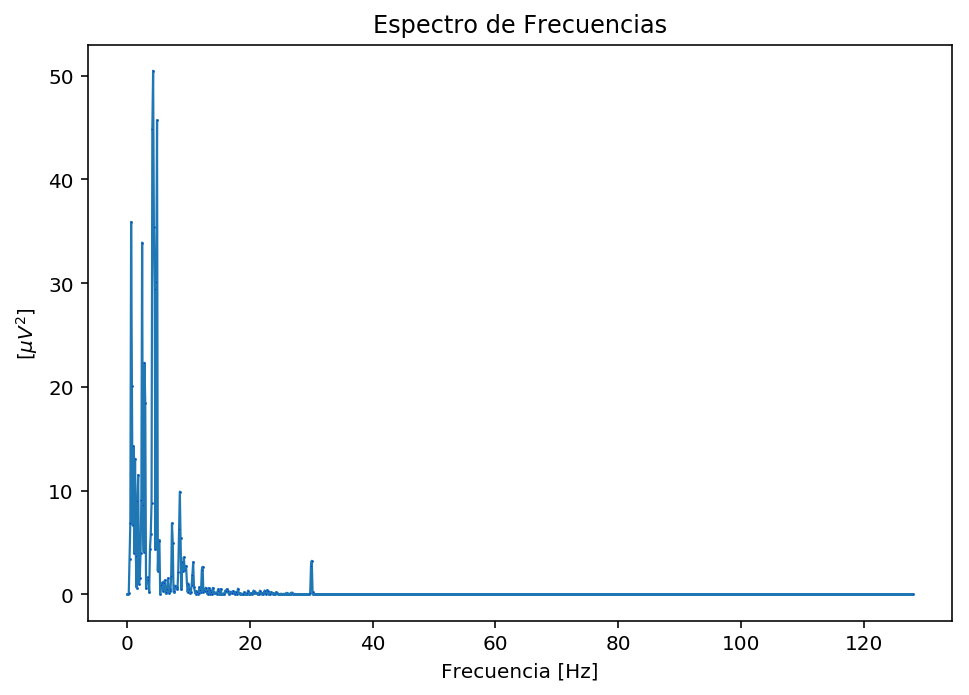

```python
fig = plt.figure()
#Ejes y márgenes
ax= fig.add_axes([0,0,1,1])

ax.plot(freqs,power,linewidth=1.1,marker = ".",markersize=1,
       markerfacecolor="blue")

ax.set_title('Espectro de Frecuencias')
ax.set_ylabel("[$\mu V^{2}$]")
ax.set_xlabel("Frecuencia [Hz]")
```

### Otra forma de obtener el PSD de una señal es simplemente calcular la transformada de Fourier de la función de autocorrelación de la señal:

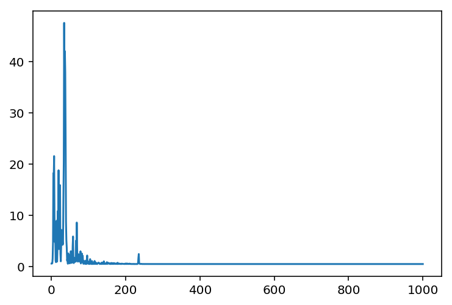

```python
plt.plot(np.fft.rfft(A))
```